# **ClusVis**

*Gaussian-Based Visualization of Gaussian and Non-Gaussian Model-Based Clustering*

**Description:**

**Site map:**

- Introduction.
- Visualization of model-based clustering of categorical data.
- Visualization of model-based clustering of functional data.

All the experiments are used with R package ClusVis.1.0

### Introduction

**ClusVis** implements a method to visualize results of Gaussian or non-Gaussian model-based clustering, on a map. It considers that model-based clustering is done by mixture model $f$, defined on the native space of the variables (possibly non-continuous). The visualization is permitted by a constrained Gaussian mixture $g$, whose the centers of the components have to be estimated. The aim is to estimate the parameters of $g$ to make $g$ as similar as possible than $f$ for the clustering purpose. However, $f$ and $g$ are not defined on the same space. In clustering, the target is to model the probabilities of classification, thus we want that $f$ and $g$ are similar for this quantity. Therefore, parameters of $g$ cannot be estimated directly from distribution $f$. The distributions $f$ and $g$ define two distributions for the ratios of probabilities of classification, denoted $p$ and $q$ respectively. Therefore, parameters of $g$ are assessed to minimize the Kullback-Leibler divergence from $q$ to $p$. Distribution $g$ is chosen to be a constrained Gaussian mixture in order to have a one-to-one relation between $g$ and $q$, to facilitate the interpretation and to easily assess the parameters. However, we discuss the use of alternated continuous distribution. The distribution $g$ is represented on a map by projection. Therefore, the proposed method provides two graphs. The first graph represents the components overlaps and the risk of misclassification. The second graph displays the scatter-plot of the observations and different levels of the probabilities of classification.

- Go to the top

### Visualization of model-based clustering of categorical data

**ClusVis** is illustrated with the analysis of the Congress data set composed of votes for each of the 435 U.S. House of Representatives Congressmen on the 16 key votes. For each vote, three levels are considered: yea, nay or unknown disposition.

**Loadings and Model-based clustering of categorical data with Rmixmod**

```r
rm(list=ls())
# Data and Package loadings
library(ClusVis)
require(Rmixmod)
data(congress)
# clustering
resmix <- mixmodCluster(congress, 4)
```

**Inference of the parameters used to visualize**

Parameters used to visualize are directly estimated from the results of function $mixmodCluster$

```r
  resvisu <- clusvisMixmod(resmix)
```

**Component interpretation graph**

ClusVis implements a component interpretation graph which represents, on the most discriminating space, the centers of the projected Gaussian components (numbers). This graph permits to see proximities between components because these centers are assessed with respects to the overlaps between the components of $f$. Moreover, we also represent the 95$\%$ confidence level (black border which separates the area outside the confidence level in white to the area inside the confidence level in gray levels) and curves of iso-probability of classification of the resulting mixture (gray levels). Finally, the accuracy of this representation is given by the difference between entropies $E(f) - E(\tilde{g})$ and the percentile of inertia by axis. We now illustrate this proposition on the running example.

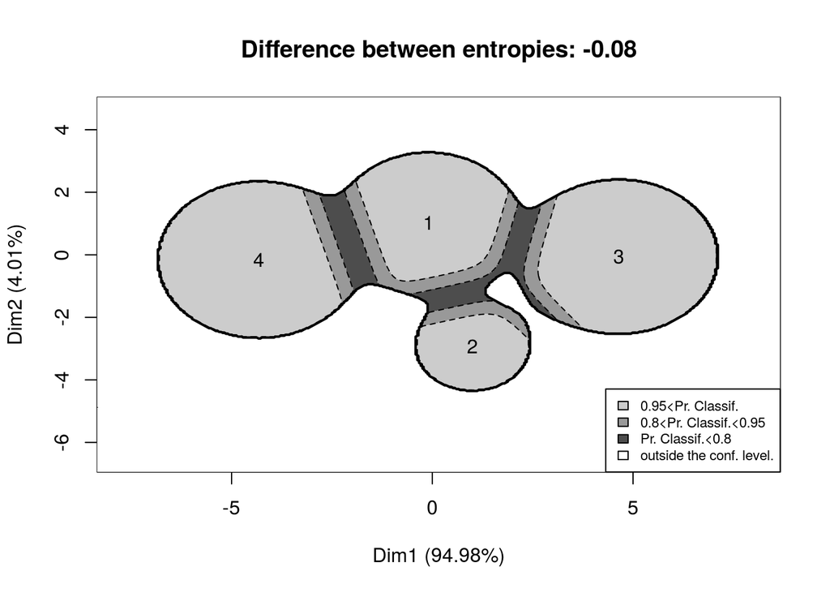

```r
  plotDensityClusVisu(resvisu, add.obs = F, positionlegend = "bottomright")
```

**Iso-probabilities of classification and scatter-plot**

ClusVis implements a scatter-plot of the observation memberships. We represent the observations by their coordinates arisen from the LDA of $g$. The partition defined by the MAP rule is given by the color of each dot. Moreover, the information about the uncertainty of classification is given by the curves of iso-probability of classification. Finally information about the visualization accuracy is given by the difference between entropies and the percentiles of inertia.

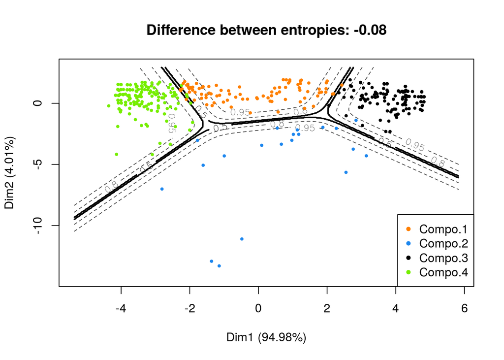

```r
  plotDensityClusVisu(resvisu, add.obs = T, positionlegend = "bottomright")
```

- Go to the top

### Visualization of model-based clustering of functional data

**Loadings and Model-based clustering of functional data with funFEM**

```r
rm(list=ls())
# Data and Package loadings
require(funFEM)
data(velib)

# clustering
basis<- create.fourier.basis(c(0, 181), nbasis=25)
fdobj <- smooth.basis(1:181,t(velib$data),basis)$fd
res = funFEM(fdobj,K=10,model='AkjB')
```

```
The "ward" method has been renamed to "ward.D"; note new "ward.D2"
```

This figure presents the curves classified among the 10 components by the MAP rule.

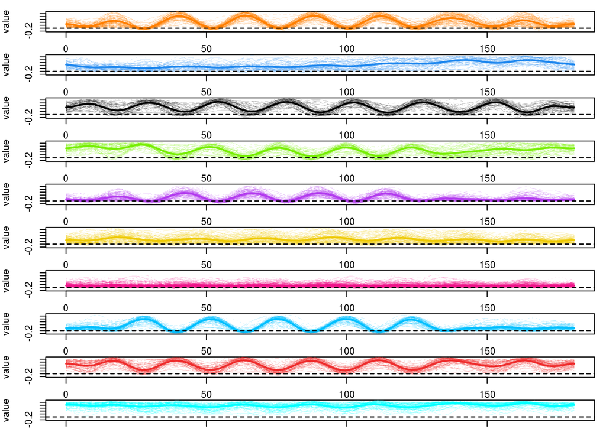

```r
# Visualization of group means
fdmeans = fdobj; fdmeans$coefs = t(res$prms$my)
colset <- c("darkorange1", "dodgerblue2", "black", "chartreuse2", "darkorchid2", "gold2", "deeppink2", "deepskyblue1", "firebrick2", "cyan1")

par(mfrow=c(10,1), mar=c(1,4,1,1))
for (k in 1:10){
  tmp <- fdobj
  who <- which(res$cls==k)
  tmp$coefs <- tmp$coefs[,who]
  colo <- rep(1, 10)-1
  colo[k] <- 2
  color <- rep("white", 10)
  color[k]= colset[k]
  lt <- rep(0, 10)
  lt[k]= 1
  plot.fd(tmp, col=colset[k], lwd=0.1, ylim=c(-0.2,1.1))
  plot(fdmeans,col=color,xaxt='n',lwd=colo, lty=lt, add=TRUE)
}
```

**Inference of the parameters used to visualize**

Parameters used to visualize can ve estimated directly from any clustering output

```r
   resmix <- clusvis(log(res$P), as.numeric(res$prms$prop))
```

**Component interpretation graph**

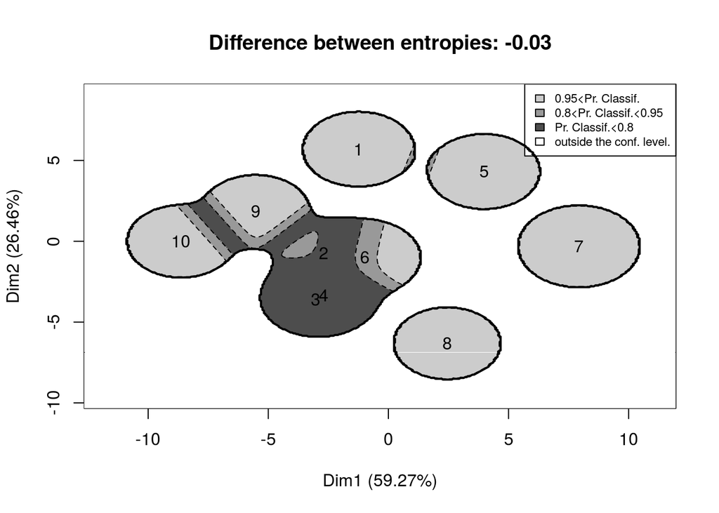

```r
plotDensityClusVisu(resmix)
```

**Iso-probabilities of classification and scatter-plot**

ClusVis implements a scatter-plot of the observation memberships. We represent the observations by their coordinates arisen from the LDA of $g$. The partition defined by the MAP rule is given by the color of each dot. Moreover, the information about the uncertainty of classification is given by the curves of iso-probability of classification. Finally information about the visualization accuracy is given by the difference between entropies and the percentiles of inertia.

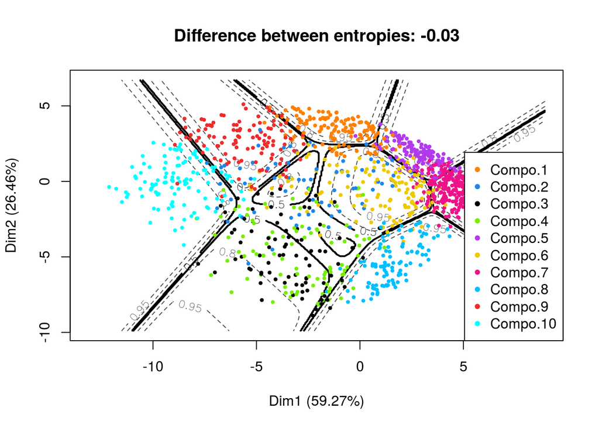

```r
plotDensityClusVisu(resmix, add.obs = T, positionlegend = "bottomright")
```

- Go to the top